# SCUDO: Signature-based Clustering for Diagnostic Purposes

Matteo Ciciani, Thomas Cantore and Enrica Colasurdo

CIBIO, Univ. of Trento, Trento, Italy

2018-06-10

#### Abstract

This package implements in R the SCUDO pipeline proposed in Lauria (2013) and Lauria, Moyseos, Priami (2015).

# 1 An introduction about the method

The aim of SCUDO is to work as a classifier for microarray-based phenotype prediction. The method is based on the idea of a sample-specific signature. The expected result is the emergence of a partitioning of the set of samples in separate groups on the basis of signature similarity.  
A first normalization step and feature selection are optionally performed. Feature selection is obtained through a Wilcoxon Rank Sum Statistics or Kruskal-Wallis Rank Sum Test depending on number of sample groups considered.  
The subsequent operations include single sample gene ranking and signature extraction (based on UpSignatures, DownSignatures values). An all-to-all distance matrix is then computed using a metric similar to the Gene Set Enrichment Analysis (GSEA): the distance is calculated finding an enrichment score (ES) of the signature of one sample against the whole list of sorted IDs.  
Consensus signtures, both for up- and down-signatures are then computed, in order to extract the overall most relevant signatures, for each of the considered groups.  
Finally, a threshold as the Nth lowest percentile of distances is used in order to produce a map as a graph, where each node represents signatures and each node is connected by an edge corresponding to their respective distance. The map can be displayed through the use of Cytoscape.

# 2 Example

Example using the *ALL* package, containing data of T- and B-cell Acute Lymphocytic Leukemia.

## 2.1 Load required packages and explore data

```r
library(scudo)
library(ALL)
data(ALL)
```

We can extract the expression data and the samples annotation.

```r
expData <- exprs(ALL)
dim(expData)
```

```
#> [1] 12625   128
```

```r
phenoData <- pData(ALL)
```

`expData` contains mRNA expression measurements for 128 samples and 12625 features. The factor `phenoData$BT` classifies the samples as B- or T-cell lymphocytic leukemia:

```r
summary(phenoData$BT)
```

```
#>  B B1 B2 B3 B4  T T1 T2 T3 T4
#>  5 19 36 23 12  5  1 15 10  2
```

We can see that there are different classes of B- and T-cell leukemia. For now we can simplify this, keeping only the distinction between B- and T-cells.

```r
bt <- as.factor(stringr::str_extract(phenoData$BT, "^."))
summary(bt)
```

```
#>  B  T
#> 95 33
```

## 2.2 Perform analysis

Rigth now the input has to be a data.frame, soon we will add matrices and ExpressionSets.

```r
expData <- as.data.frame(expData)
ScudoRes <- scudo(expData, groups = bt, nTop = 100, nBottom = 100, pValue = 0.1)
ScudoRes
```

```
#> Scudo Results Object
#>
#> Class                  :  ScudoResults
#> Number of samples      :  128
#> UpSignatures           :  100
#> DownSignatures         :  100
#> Number of groups       :  2
#> Normalization          :  TRUE
#> Feature selection
#>   Performed            :  TRUE
#>   Test                 :  Wilcoxon Rank Sum statistic
#>   pValue               :  0.1
#>   p.adj method         :  none
#>   selected features    :  5468
```

From this object we can extract the signatures for each sample and the consensus signatures for each group.

```r
UpSig <- UpSignatures(ScudoRes)
UpSig[1:5,1:5]
```

```
#>      01005      01010    03002      04006    04007
#> 1 36543_at    1183_at 36543_at   36638_at 40367_at
#> 2 35362_at   37006_at 33462_at   34721_at 36638_at
#> 3 40953_at   32523_at 33910_at 37251_s_at  1113_at
#> 4 36275_at   40749_at 36275_at   40763_at 35352_at
#> 5 39389_at 38522_s_at 38510_at   34106_at 36908_at
```

```r
ConsUpSig <- ConsensusUpSignatures(ScudoRes)
ConsUpSig[1:5, ]
```

```
#>            B         T
#> 1 38096_f_at  38319_at
#> 2 38095_i_at  38147_at
#> 3   35016_at  33238_at
#> 4   37039_at  37078_at
#> 5   39839_at 2059_s_at
```

The object `ScudoRes` can be used to generate a network of samples, as an *igraph*object, using the function `ScudoNetwork`.

```r
net <- ScudoNetwork(ScudoRes, N = 0.2)
```

The parameter `N` controls the percentage of edges to keep in the network. We can plot this network using the usual `plot` function.

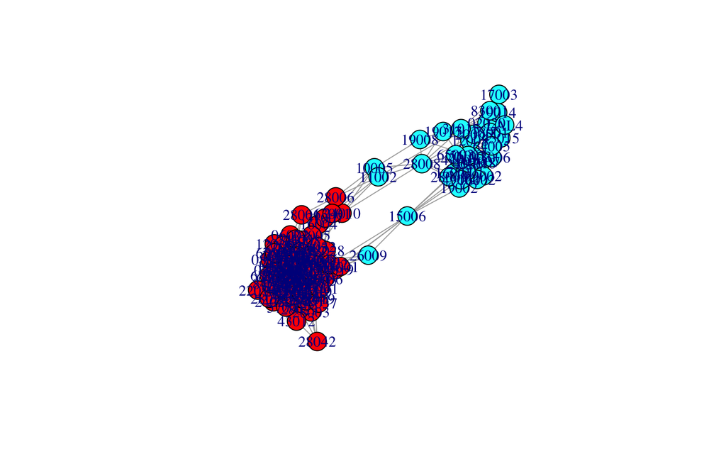

```r
plot(net)
```

This plot is useful to have a quick look at the network, but is rather ugly. We can render the network in Cytoscape, using the function `ScudoCytoscape`. Note that Cytoscape has to be open when running the function.

```r
ScudoCytoscape(net)
```

# 3 References

Mario Lauria. Rank-based transcriptional signatures. Systems Biomedicine. 2013; 1(4):228-239.

Mario Lauria, Petros Moyseos and Corrado Priami. SCUDO: a tool for signature-based clustering of expression profiles. Nucleic Acids Research. 2015; 43(W1):W188-92.